# Barbell Lift Analysis with Body Monitoring

Paul Jefferies

January 19, 2017

## Summary

Barbell bicept curling motion is evaluated using body and weight sensors to assess whether these measurements can be used to predict good form and completeness. This data and study is based on the paper by Vellosso, E., et.al titled [Qualitative Activity Recognition of Weight Lifting Exercises](http://groupware.les.inf.puc-rio.br/work.jsf?p1=11201).

## Data Processing

### Load Data from cloudfront.net data repository

```r
trainData <- read.csv("https://d396qusza40orc.cloudfront.net/predmachlearn/pml-training.csv")
testData  <- read.csv("https://d396qusza40orc.cloudfront.net/predmachlearn/pml-testing.csv")
```

### Review the Data

```r
#First let's look at the trainData dataset
trainData.RowsCols <- dim(trainData)
trainData.noSparse <- sum(colSums(is.na(trainData))>nrow(trainData)*0.95)
trainData.ratioSparse <- round(trainData.noSparse/ncol(trainData),2)
trainData.FirstVars <- colnames(trainData)[1:10]
trainData.ResultCount <- table(trainData$classe)

testData.RowsCols <- dim(testData)
testData.NACols <- sum((colSums(is.na(testData))==nrow(testData))*1)
```

#### Training Set Summary

- Variables: 160
- Samples: 19622
- No. of Sparse Variables: 67
- Ratio of Sparce Variables: 0.42
- List of First Few Variables: X, user_name, raw_timestamp_part_1, raw_timestamp_part_2, cvtd_timestamp, new_window, num_window, roll_belt, pitch_belt, yaw_belt
- Count of Result Values: 5580, 3797, 3422, 3216, 3607
- Since there are greater than 40% sparse variables, we should consider whether to use only the samples that contain all of the variables.
- In the first few variables, we see names, times and window information that won’t be used for model fitting and can be removed.
- Looking at the results variable, although there are many more of the first factor (‘A’ / successful forms), there is still a good distribution of the levels.

#### Test Set Summary

- Variables: 160
- Samples: 20
- No. of Empty Variables: 100
- The 100 of 160 empty columns in the test data are empty and can be removed from the dataset. The remaining columns will be used to predict (also eliminating X, name, time and window variables). Since we can’t predict with variables other than these, all other variables can be removed from the training dataset

### Clean-up Data

- Remove empty columns/variables from test dataset
- Remove all variables from the training set that are not in the test set since these can’t be use to predict
- Remove all traing dataset rows that are not labeled as a new_window to capture only the importan measurement, not intermediate ones
- Remove row numbers, user name, timestamp, window variables from the datasets since we don’t want to use these data to train or predict.

```r
#Find variables in testData without NAs. These will be used for predictions.
testDataNAs <- data.frame(isAnNA = colSums(is.na(testData))==nrow(testData))
testDataNotNAs <- rownames(subset(testDataNAs, !isAnNA))
testDataIsNAs <- rownames(subset(testDataNAs, isAnNA))

#All other variables can be ignored in test and training data sets.
testDataSm <- subset(testData, select=testDataNotNAs)

#Remove all variables that are not in test data as we can't use them predict anyway
trainDataSm <- trainData[!(names(trainData) %in% testDataIsNAs)]

#Remove all rows that are not new_window
trainDataSm <- trainDataSm[trainDataSm$new_window=="yes", ]

#Remove line_no, user, times and window reference as they are not planned to be used
trainDataSm <- subset(trainDataSm, select=-c(X, user_name,
                                             raw_timestamp_part_1,
                                             raw_timestamp_part_2,
                                             cvtd_timestamp, new_window,
                                             num_window))
testDataSm <- subset(testDataSm, select=-c(X, user_name,
                                           raw_timestamp_part_1,
                                           raw_timestamp_part_2,
                                           cvtd_timestamp, new_window,
                                           num_window))
```

### Create folds for cross-validation

- Number of folds = 10
- Each fold has 90% in sub-training dataset and 10% in sub-test dataset

```r
#Create k-Folds for Cross-validataion with k=10
library(caret)
set.seed(52738)
folds <- createFolds(y=trainDataSm$classe,
                     k=10,
                     list=TRUE,
                     returnTrain=TRUE)
```

### Run Random Forest Fit Algorithm on each fold

- Create a list to save each fold model so that the best one can be chosen at the end
- Create a list of the accuracy of each fold model bases on sub-sampling to use to judge each model

```r
#create an empty lists for holding fit result and each fit's accuracy
modFitTemp <- vector("list", length(folds))
accuracyFit <- vector("numeric", length(folds))

#For each fold, use Random Forest to find best fit, predict on sub-test
#dataset and measure accuracy
for(i in 1:length(folds)) {
  trainDataTemp <- trainDataSm[folds[[i]], ]
  testDataTemp <- trainDataSm[-folds[[i]], ]
  modFitTemp[[i]] <- train(classe ~ .,
                           data=trainDataTemp,
                           method="rf",
                           prox=TRUE)
  predTemp <- predict(modFitTemp[[i]], testDataTemp)
  accuracyFit[[i]] <- sum(predTemp == testDataTemp$classe)*1/length(predTemp)
}
```

## Results

### Show values and plot of accuracies by fold

```
   accuracyFit
1        0.805
2        0.829
3        0.707
4        0.875
5        0.634
6        0.800
7        0.775
8        0.854
9        0.805
10       0.750
```

```
[1] "The mean of 10 k-folds accuracy is 0.783. This is an estimation of the out of sample error."
```

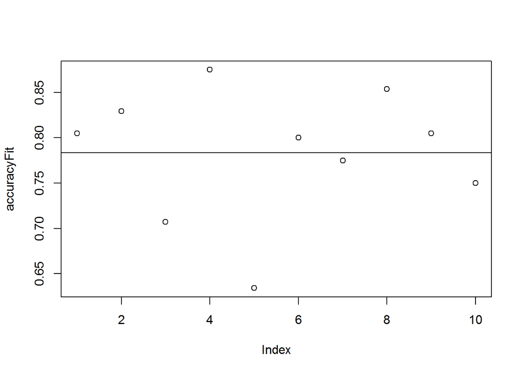

### Pick the Best Prediction Model, Explain Why and Assess Expected Sample Error

- Pick the fold that is closest to the average of all folds: - Why? - Trade-off between the best fit accuracy and avoiding overfitting

```
[1] "Best Avg. Cluster number: 7"
```

```
[1] "The best model fit was the following:"
```

```
[[1]]
Random Forest

366 samples
 52 predictor
  5 classes: 'A', 'B', 'C', 'D', 'E'

No pre-processing
Resampling: Bootstrapped (25 reps)
Summary of sample sizes: 366, 366, 366, 366, 366, 366, ...
Resampling results across tuning parameters:

  mtry  Accuracy   Kappa
   2    0.6893710  0.6069740
  27    0.6893570  0.6078814
  52    0.6706836  0.5846677

Accuracy was used to select the optimal model using  the largest value.
The final value used for the model was mtry = 2.
```

### Predict the Results of the Original testData dataset with the Best Fold Random Forest model

```
[1] "The prediction for the test data set are as follows:"
```

```
   Prediction
1           C
2           A
3           C
4           A
5           A
6           E
7           D
8           B
9           A
10          A
11          B
12          C
13          A
14          A
15          E
16          E
17          A
18          B
19          A
20          B
```